# EasyVisa Project

## Context:

Business communities in the United States are facing high demand for human resources, but one of the constant challenges is identifying and attracting the right talent, which is perhaps the most important element in remaining competitive. Companies in the United States look for hard-working, talented, and qualified individuals both locally as well as abroad.

The Immigration and Nationality Act (INA) of the US permits foreign workers to come to the United States to work on either a temporary or permanent basis. The act also protects US workers against adverse impacts on their wages or working conditions by ensuring US employers' compliance with statutory requirements when they hire foreign workers to fill workforce shortages. The immigration programs are administered by the Office of Foreign Labor Certification (OFLC).

OFLC processes job certification applications for employers seeking to bring foreign workers into the United States and grants certifications in those cases where employers can demonstrate that there are not sufficient US workers available to perform the work at wages that meet or exceed the wage paid for the occupation in the area of intended employment.

## Objective:

In FY 2016, the OFLC processed 775,979 employer applications for 1,699,957 positions for temporary and permanent labor certifications. This was a nine percent increase in the overall number of processed applications from the previous year. The process of reviewing every case is becoming a tedious task as the number of applicants is increasing every year.

The increasing number of applicants every year calls for a Machine Learning based solution that can help in shortlisting the candidates having higher chances of VISA approval. OFLC has hired your firm EasyVisa for data-driven solutions. You as a data scientist have to analyze the data provided and, with the help of a classification model:

- Facilitate the process of visa approvals.
- Recommend a suitable profile for the applicants for whom the visa should be certified or denied based on the drivers that significantly influence the case status.

## Data Description

The data contains the different attributes of the employee and the employer. The detailed data dictionary is given below.

- case_id: ID of each visa application
- continent: Information of continent the employee
- education_of_employee: Information of education of the employee
- has_job_experience: Does the employee has any job experience? Y= Yes; N = No
- requires_job_training: Does the employee require any job training? Y = Yes; N = No
- no_of_employees: Number of employees in the employer's company
- yr_of_estab: Year in which the employer's company was established
- region_of_employment: Information of foreign worker's intended region of employment in the US.
- prevailing_wage: Average wage paid to similarly employed workers in a specific occupation in the area of intended employment. The purpose of the prevailing wage is to ensure that the foreign worker is not underpaid compared to other workers offering the same or similar service in the same area of employment.
- unit_of_wage: Unit of prevailing wage. Values include Hourly, Weekly, Monthly, and Yearly.
- full_time_position: Is the position of work full-time? Y = Full Time Position; N = Part Time Position
- case_status: Flag indicating if the Visa was certified or denied

## Importing necessary libraries and data

```python
# Installing the libraries with the specified version.
#!pip install numpy==1.25.2 pandas==1.5.3 scikit-learn==1.2.2 matplotlib==3.7.1 seaborn==0.13.1 xgboost==2.0.3
```

- Above libraries extensions are not required on Google Colab

**Note**: *After running the above cell, kindly restart the notebook kernel and run all cells sequentially from the start again.*

Importing all necessary libraries to work on data set

```python
import warnings

warnings.filterwarnings("ignore")

# Libraries to help with reading and manipulating data
import numpy as np
import pandas as pd

# Library to split data
from sklearn.model_selection import train_test_split

# libaries to help with data visualization
import matplotlib.pyplot as plt
import seaborn as sns

# Removes the limit for the number of displayed columns
pd.set_option("display.max_columns", None)
# Sets the limit for the number of displayed rows
pd.set_option("display.max_rows", 100)


# Libraries different ensemble classifiers
from sklearn.ensemble import (
    BaggingClassifier,
    RandomForestClassifier,
    AdaBoostClassifier,
    GradientBoostingClassifier,
    StackingClassifier,
)

from xgboost import XGBClassifier
from sklearn.tree import DecisionTreeClassifier

# Libraries to get different metric scores
from sklearn import metrics
from sklearn.metrics import (
    confusion_matrix,
    accuracy_score,
    precision_score,
    recall_score,
    f1_score,
)

# To tune different models
from sklearn.model_selection import GridSearchCV, RandomizedSearchCV
```

## Importing data and creating data frame

```python
from google.colab import files
uploaded = files.upload()
```

Upload widget is only available when the cell has been executed in the current browser session. Please rerun this cell to enable.

```
Saving EasyVisa.csv to EasyVisa.csv
```

```python
Easy_visa = pd.read_csv('EasyVisa.csv') ##   reading the data
```

```python
# copying data to another variable to avoid any changes to original data
data = Easy_visa.copy()
```

- Above we have import the data from local drive.
- Read the data and Create the data frame using pandas.
- Create a copy of originla data to avoid and changes to orginla data set.

## Data Overview

- Observations
- Sanity checks

View the first and last 5 rows of the dataset

```python
#checking top 5 rows of data set
data.head()
```

|  | case_id | continent | education_of_employee | has_job_experience | requires_job_training | no_of_employees | yr_of_estab | region_of_employment | prevailing_wage | unit_of_wage | full_time_position | case_status |
| --- | --- | --- | --- | --- | --- | --- | --- | --- | --- | --- | --- | --- |
| 0 | EZYV01 | Asia | High School | N | N | 14513 | 2007 | West | 592.2029 | Hour | Y | Denied |
| 1 | EZYV02 | Asia | Master's | Y | N | 2412 | 2002 | Northeast | 83425.6500 | Year | Y | Certified |
| 2 | EZYV03 | Asia | Bachelor's | N | Y | 44444 | 2008 | West | 122996.8600 | Year | Y | Denied |
| 3 | EZYV04 | Asia | Bachelor's | N | N | 98 | 1897 | West | 83434.0300 | Year | Y | Denied |
| 4 | EZYV05 | Africa | Master's | Y | N | 1082 | 2005 | South | 149907.3900 | Year | Y | Certified |

```python
#checking last 5 rows of data set
data.tail()
```

|  | case_id | continent | education_of_employee | has_job_experience | requires_job_training | no_of_employees | yr_of_estab | region_of_employment | prevailing_wage | unit_of_wage | full_time_position | case_status |
| --- | --- | --- | --- | --- | --- | --- | --- | --- | --- | --- | --- | --- |
| 25475 | EZYV25476 | Asia | Bachelor's | Y | Y | 2601 | 2008 | South | 77092.57 | Year | Y | Certified |
| 25476 | EZYV25477 | Asia | High School | Y | N | 3274 | 2006 | Northeast | 279174.79 | Year | Y | Certified |
| 25477 | EZYV25478 | Asia | Master's | Y | N | 1121 | 1910 | South | 146298.85 | Year | N | Certified |
| 25478 | EZYV25479 | Asia | Master's | Y | Y | 1918 | 1887 | West | 86154.77 | Year | Y | Certified |
| 25479 | EZYV25480 | Asia | Bachelor's | Y | N | 3195 | 1960 | Midwest | 70876.91 | Year | Y | Certified |

- There are 12 columns and most of them are categorial variable, only 3 numerical cloums can be seen
- Columns with categories are required to replace with binary values and convert them to Int or Float at later stage so that model can read the values.

Checking the shape of the dataset

```python
## Checking the dimensions of the data set
data.shape
```

```
(25480, 12)
```

- There are 25480 Rows and 12 Columns in data

Checking data types of the columns for the dataset

```python
## Checking the data types of the data
data.info()
```

```
<class 'pandas.core.frame.DataFrame'>
RangeIndex: 25480 entries, 0 to 25479
Data columns (total 12 columns):
 #   Column                 Non-Null Count  Dtype
---  ------                 --------------  -----
 0   case_id                25480 non-null  object
 1   continent              25480 non-null  object
 2   education_of_employee  25480 non-null  object
 3   has_job_experience     25480 non-null  object
 4   requires_job_training  25480 non-null  object
 5   no_of_employees        25480 non-null  int64
 6   yr_of_estab            25480 non-null  int64
 7   region_of_employment   25480 non-null  object
 8   prevailing_wage        25480 non-null  float64
 9   unit_of_wage           25480 non-null  object
 10  full_time_position     25480 non-null  object
 11  case_status            25480 non-null  object
dtypes: float64(1), int64(2), object(9)
memory usage: 2.3+ MB
```

- There are 12 columns, 9 Columns are object values, 2 columns have integer values and 1 colum have float Vlaves

Checking Missing values in data set

```python
# Checking for null Values in data
data.isnull().sum()
```

|  | 0 |
| --- | --- |
| case_id | 0 |
| continent | 0 |
| education_of_employee | 0 |
| has_job_experience | 0 |
| requires_job_training | 0 |
| no_of_employees | 0 |
| yr_of_estab | 0 |
| region_of_employment | 0 |
| prevailing_wage | 0 |
| unit_of_wage | 0 |
| full_time_position | 0 |
| case_status | 0 |

**dtype:** int64

- There are no missing values in any of the column's

checking for duplicate values

```python
## checking for duplicate values
data.duplicated().sum()
```

```
0
```

- There are no duplicate values in data set.

Let's check the count of each unique category in the categorical variables

```python
# Making a list of all catrgorical variables
cat_col = list(data.select_dtypes("object").columns)

# Printing number of count of each unique value in each column
for column in cat_col:
    print(data[column].value_counts())
    print(" - " * 30)
```

```
case_id
EZYV01       1
EZYV16995    1
EZYV16993    1
EZYV16992    1
EZYV16991    1
            ..
EZYV8492     1
EZYV8491     1
EZYV8490     1
EZYV8489     1
EZYV25480    1
Name: count, Length: 25480, dtype: int64
 -  -  -  -  -  -  -  -  -  -  -  -  -  -  -  -  -  -  -  -  -  -  -  -  -  -  -  -  -  -
continent
Asia             16861
Europe            3732
North America     3292
South America      852
Africa             551
Oceania            192
Name: count, dtype: int64
 -  -  -  -  -  -  -  -  -  -  -  -  -  -  -  -  -  -  -  -  -  -  -  -  -  -  -  -  -  -
education_of_employee
Bachelor's     10234
Master's        9634
High School     3420
Doctorate       2192
Name: count, dtype: int64
 -  -  -  -  -  -  -  -  -  -  -  -  -  -  -  -  -  -  -  -  -  -  -  -  -  -  -  -  -  -
has_job_experience
Y    14802
N    10678
Name: count, dtype: int64
 -  -  -  -  -  -  -  -  -  -  -  -  -  -  -  -  -  -  -  -  -  -  -  -  -  -  -  -  -  -
requires_job_training
N    22525
Y     2955
Name: count, dtype: int64
 -  -  -  -  -  -  -  -  -  -  -  -  -  -  -  -  -  -  -  -  -  -  -  -  -  -  -  -  -  -
```

[output cut: 10 more lines]

```
Hour      2157
Week       272
Month       89
Name: count, dtype: int64
 -  -  -  -  -  -  -  -  -  -  -  -  -  -  -  -  -  -  -  -  -  -  -  -  -  -  -  -  -  -
full_time_position
Y    22773
N     2707
Name: count, dtype: int64
 -  -  -  -  -  -  -  -  -  -  -  -  -  -  -  -  -  -  -  -  -  -  -  -  -  -  -  -  -  -
case_status
Certified    17018
Denied        8462
Name: count, dtype: int64
 -  -  -  -  -  -  -  -  -  -  -  -  -  -  -  -  -  -  -  -  -  -  -  -  -  -  -  -  -  -
```

- Case Id have all the unique values
- In Continent Variable, Asia have the highest count followed by Europe.
- In Education of employee variable, Bachelors have the highest count followed by masters degree.
- In Has Job experience , applications with experience have higher count then without experience.
- Required Job training, applicants who do not need job training have higher count then applicants need job training.
- In region of employment, Northeast have highest count folowed by south.
- Yearly wages have highest count followed by hourly wages in unit of wage variable.
- In ful time position variable, full time jobs have higher count then part time.
- In Case status certified category have higher count then denied category.

## Exploratory Data Analysis (EDA)

- EDA is an important part of any project involving data.
- It is important to investigate and understand the data better before building a model with it.
- A few questions have been mentioned below which will help you approach the analysis in the right manner and generate insights from the data.
- A thorough analysis of the data, in addition to the questions mentioned below, should be done.

Lets check the statistical summary of the data first before we proceed to questions asked which required univariate and bivariate analyses

```python
## Checking the statistical summary of the data
data.describe(include="all").T
```

|  | count | unique | top | freq | mean | std | min | 25% | 50% | 75% | max |
| --- | --- | --- | --- | --- | --- | --- | --- | --- | --- | --- | --- |
| case_id | 25480 | 25480 | EZYV01 | 1 | NaN | NaN | NaN | NaN | NaN | NaN | NaN |
| continent | 25480 | 6 | Asia | 16861 | NaN | NaN | NaN | NaN | NaN | NaN | NaN |
| education_of_employee | 25480 | 4 | Bachelor's | 10234 | NaN | NaN | NaN | NaN | NaN | NaN | NaN |
| has_job_experience | 25480 | 2 | Y | 14802 | NaN | NaN | NaN | NaN | NaN | NaN | NaN |
| requires_job_training | 25480 | 2 | N | 22525 | NaN | NaN | NaN | NaN | NaN | NaN | NaN |
| no_of_employees | 25480.0 | NaN | NaN | NaN | 5667.04321 | 22877.928848 | -26.0 | 1022.0 | 2109.0 | 3504.0 | 602069.0 |
| yr_of_estab | 25480.0 | NaN | NaN | NaN | 1979.409929 | 42.366929 | 1800.0 | 1976.0 | 1997.0 | 2005.0 | 2016.0 |
| region_of_employment | 25480 | 5 | Northeast | 7195 | NaN | NaN | NaN | NaN | NaN | NaN | NaN |
| prevailing_wage | 25480.0 | NaN | NaN | NaN | 74455.814592 | 52815.942327 | 2.1367 | 34015.48 | 70308.21 | 107735.5125 | 319210.27 |
| unit_of_wage | 25480 | 4 | Year | 22962 | NaN | NaN | NaN | NaN | NaN | NaN | NaN |
| full_time_position | 25480 | 2 | Y | 22773 | NaN | NaN | NaN | NaN | NaN | NaN | NaN |
| case_status | 25480 | 2 | Certified | 17018 | NaN | NaN | NaN | NaN | NaN | NaN | NaN |

Before we proceed with Questions asked, lets fix the negative values in number of employees columns and drop the Case_Id colum as all the values are unique

```python
#Checking how many negetive values are there in number of employee column
negative_values_mask = data["no_of_employees"] < 0  # Get a boolean mask
negative_values_count = negative_values_mask.sum()  # Get the count of negative values
print(f"There are {negative_values_count} negative values in 'no_of_employees'")
```

```
There are 33 negative values in 'no_of_employees'
```

```python
# taking the absolute values for number of employees
data['no_of_employees'] = data['no_of_employees'].abs()
```

```python
#Re-Checking if there are still negetive values  in number of employee column
negative_values_mask_new = data["no_of_employees"] < 0  # Get a boolean mask
negative_values_count_new = negative_values_mask_new.sum()  # Get the count of negative values
print(f"There are {negative_values_count_new} negative values in 'no_of_employees'")
```

```
There are 0 negative values in 'no_of_employees'
```

```python
## Checking minimum value for no_of_employee column after treating Negetive value
data['no_of_employees'].min()
```

```
11
```

- After treatment of negative values the minimum values for no of employees have been change to 11 form -26.0.

```python
## Dropping Case_id column
data.drop('case_id',axis=1,inplace=True)
```

```python
# Checking Top 5 rows after dropping case_id column
data.head()
```

|  | continent | education_of_employee | has_job_experience | requires_job_training | no_of_employees | yr_of_estab | region_of_employment | prevailing_wage | unit_of_wage | full_time_position | case_status |
| --- | --- | --- | --- | --- | --- | --- | --- | --- | --- | --- | --- |
| 0 | Asia | High School | N | N | 14513 | 2007 | West | 592.2029 | Hour | Y | Denied |
| 1 | Asia | Master's | Y | N | 2412 | 2002 | Northeast | 83425.6500 | Year | Y | Certified |
| 2 | Asia | Bachelor's | N | Y | 44444 | 2008 | West | 122996.8600 | Year | Y | Denied |
| 3 | Asia | Bachelor's | N | N | 98 | 1897 | West | 83434.0300 | Year | Y | Denied |
| 4 | Africa | Master's | Y | N | 1082 | 2005 | South | 149907.3900 | Year | Y | Certified |

**Leading Questions**:

1. Those with higher education may want to travel abroad for a well-paid job. Does education play a role in Visa certification?
2. How does the visa status vary across different continents?
3. Experienced professionals might look abroad for opportunities to improve their lifestyles and career development. Does work experience influence visa status?
4. In the United States, employees are paid at different intervals. Which pay unit is most likely to be certified for a visa?
5. The US government has established a prevailing wage to protect local talent and foreign workers. How does the visa status change with the prevailing wage?

lets begain with the questions and if all the variable analysis will not covered in questions, then will do additional EDA (Univeriate or bivariate analyses) at later stage.

Defining function to create various plots which will help for EDA.

```python
## Defining function to create hist plot, box plot
def histogram_boxplot(data, feature, figsize=(15, 10), kde=False, bins=None):
    """
    Boxplot and histogram combined

    data: dataframe
    feature: dataframe column
    figsize: size of figure (default (15,10))
    kde: whether to show the density curve (default False)
    bins: number of bins for histogram (default None)
    """
    f2, (ax_box2, ax_hist2) = plt.subplots(
        nrows=2,  # Number of rows of the subplot grid= 2
        sharex=True,  # x-axis will be shared among all subplots
        gridspec_kw={"height_ratios": (0.25, 0.75)},
        figsize=figsize,
    )  # creating the 2 subplots
    sns.boxplot(
        data=data, x=feature, ax=ax_box2, showmeans=True, color="violet"
    )  # boxplot will be created and a triangle will indicate the mean value of the column
    sns.histplot(
        data=data, x=feature, kde=kde, ax=ax_hist2, bins=bins
    ) if bins else sns.histplot(
        data=data, x=feature, kde=kde, ax=ax_hist2
    )  # For histogram
    ax_hist2.axvline(
        data[feature].mean(), color="green", linestyle="--"
    )  # Add mean to the histogram
    ax_hist2.axvline(
        data[feature].median(), color="black", linestyle="-"
    )  # Add median to the histogram
```

```python
# Defining function to create labeled barplots


def labeled_barplot(data, feature, perc=False, n=None):
    """
    Barplot with percentage at the top

    data: dataframe
    feature: dataframe column
    perc: whether to display percentages instead of count (default is False)
    n: displays the top n category levels (default is None, i.e., display all levels)
    """

    total = len(data[feature])  # length of the column
    count = data[feature].nunique()
    if n is None:
        plt.figure(figsize=(count + 2, 6))
    else:
        plt.figure(figsize=(n + 2, 6))

    plt.xticks(rotation=90, fontsize=15)
    ax = sns.countplot(
        data=data,
        x=feature,
        palette="Paired",
        order=data[feature].value_counts().index[:n],
    )

    for p in ax.patches:
        if perc == True:
            label = "{:.1f}%".format(
                100 * p.get_height() / total
            )  # percentage of each class of the category
        else:
            label = p.get_height()  # count of each level of the category

        x = p.get_x() + p.get_width() / 2  # width of the plot
        y = p.get_height()  # height of the plot

        ax.annotate(
            label,
            (x, y),
            ha="center",
            va="center",
            size=12,
            xytext=(0, 5),
            textcoords="offset points",
        )  # annotate the percentage

    plt.show()  # show the plot
```

```python
### Defining function to plot distributions wrt target


def distribution_plot_wrt_target(data, predictor, target):

    fig, axs = plt.subplots(2, 2, figsize=(12, 10))

    target_uniq = data[target].unique()

    axs[0, 0].set_title("Distribution of target for target=" + str(target_uniq[0]))
    sns.histplot(
        data=data[data[target] == target_uniq[0]],
        x=predictor,
        kde=True,
        ax=axs[0, 0],
        color="teal",
        stat="density",
    )

    axs[0, 1].set_title("Distribution of target for target=" + str(target_uniq[1]))
    sns.histplot(
        data=data[data[target] == target_uniq[1]],
        x=predictor,
        kde=True,
        ax=axs[0, 1],
        color="orange",
        stat="density",
    )

    axs[1, 0].set_title("Boxplot w.r.t target")
    sns.boxplot(data=data, x=target, y=predictor, ax=axs[1, 0], palette="gist_rainbow")

    axs[1, 1].set_title("Boxplot (without outliers) w.r.t target")
    sns.boxplot(
        data=data,
        x=target,
        y=predictor,
        ax=axs[1, 1],
        showfliers=False,
        palette="gist_rainbow",
    )

    plt.tight_layout()
    plt.show()
```

```python
### Defining function for stacked bar plots wrt target
def stacked_barplot(data, predictor, target):
    """
    Print the category counts and plot a stacked bar chart

    data: dataframe
    predictor: independent variable
    target: target variable
    """
    count = data[predictor].nunique()
    sorter = data[target].value_counts().index[-1]
    tab1 = pd.crosstab(data[predictor], data[target], margins=True).sort_values(
        by=sorter, ascending=False
    )
    print(tab1)
    print("-" * 120)
    tab = pd.crosstab(data[predictor], data[target], normalize="index").sort_values(
        by=sorter, ascending=False
    )
    tab.plot(kind="bar", stacked=True, figsize=(count + 5, 5))
    plt.legend(
        loc="lower left", frameon=False,
    )
    plt.legend(loc="upper left", bbox_to_anchor=(1, 1))
    plt.show()
```

**Question 1:- Those with higher education may want to travel abroad for a well-paid job. Does education play a role in Visa certification?**

```
case_status            Certified  Denied    All
education_of_employee
All                        17018    8462  25480
Bachelor's                  6367    3867  10234
High School                 1164    2256   3420
Master's                    7575    2059   9634
Doctorate                   1912     280   2192
------------------------------------------------------------------------------------------------------------------------
```

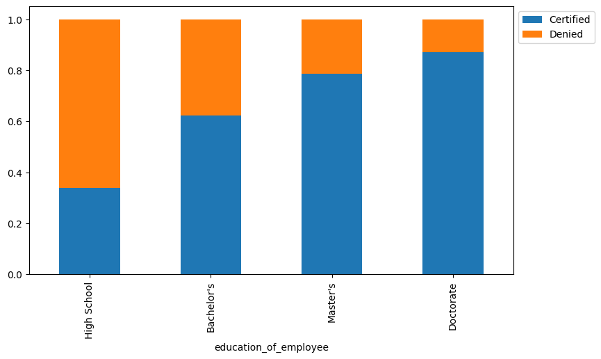

```python
## Creating barplot for education of employee vs case status
stacked_barplot(data,'education_of_employee','case_status')
```

**Question 2:- How does the visa status vary across different continents?**

```
case_status    Certified  Denied    All
continent
All                17018    8462  25480
Asia               11012    5849  16861
North America       2037    1255   3292
Europe              2957     775   3732
South America        493     359    852
Africa               397     154    551
Oceania              122      70    192
------------------------------------------------------------------------------------------------------------------------
```

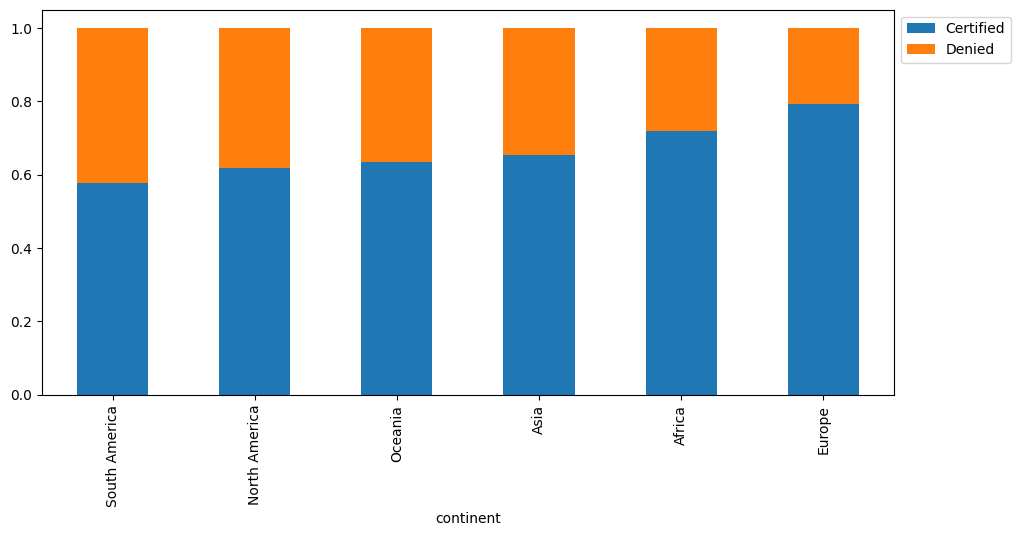

```python
# Checing barplot for case stauts vs continents
stacked_barplot(data,'continent','case_status')
```

```python
# Calculate the number of approved applications for each continent
Continent_approved_count = data[data['case_status'] == 'Certified'].groupby("continent").size()

# Calculate the total number of applications in each continent
Continent_total_count = data.groupby('continent').size()

# Calculate the percentage of approved applications
Continent_approval_percentage = (Continent_approved_count/ Continent_total_count) * 100

# Print the results
print(Continent_approval_percentage)
```

```
continent
Africa           72.050817
Asia             65.310480
Europe           79.233655
North America    61.877278
Oceania          63.541667
South America    57.863850
dtype: float64
```

- Europe have the highest percentage of Visa approvals with 79.23%, followed by Africa with 72.05%
- South America have the lowest percentage of visa approvals, Asia, North america and Oceania have between 60 to 65% approvals.

**Question 3:- Experienced professionals might look abroad for opportunities to improve their lifestyles and career development. Does work experience influence visa status?**

```
case_status         Certified  Denied    All
has_job_experience
All                     17018    8462  25480
N                        5994    4684  10678
Y                       11024    3778  14802
------------------------------------------------------------------------------------------------------------------------
```

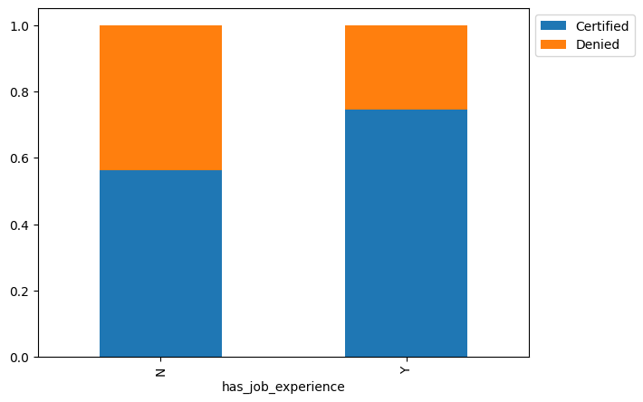

```python
#Checking Bar plot for has_job_experience vs case status
stacked_barplot(data,'has_job_experience','case_status')
```

```python
# Calculate the number of approved applications for each continent
Experience_approved_count = data[data['case_status'] == 'Certified'].groupby("has_job_experience").size()

# Calculate the total number of applications in each continent
Experience_total_count = data.groupby('has_job_experience').size()

# Calculate the percentage of approved applications
Experience_approval_percentage = (Experience_approved_count/ Experience_total_count) * 100

# Print the results
print(Experience_approval_percentage)
```

```
has_job_experience
N    56.134108
Y    74.476422
dtype: float64
```

- Applications with job experience has higher chance of getting visa approved

**Question 4:- In the United States, employees are paid at different intervals. Which pay unit is most likely to be certified for a visa?**

```
case_status   Certified  Denied    All
unit_of_wage
All               17018    8462  25480
Year              16047    6915  22962
Hour                747    1410   2157
Week                169     103    272
Month                55      34     89
------------------------------------------------------------------------------------------------------------------------
```

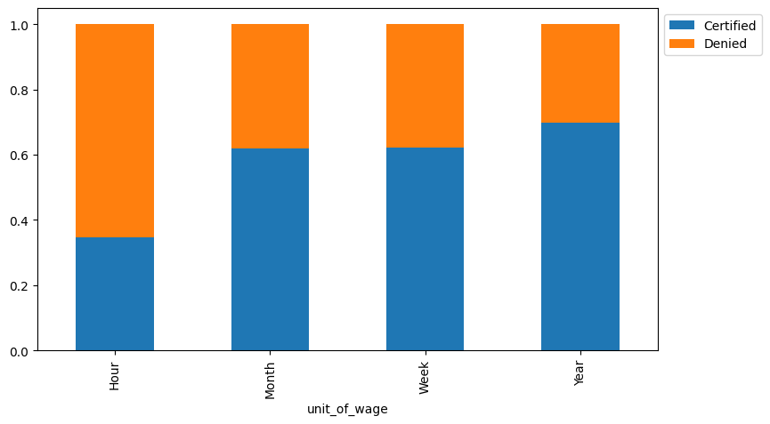

```python
#Creating bar plot for unit_of_wage vs Case status
stacked_barplot(data,'unit_of_wage','case_status')
```

- Yearly wages unit have highest percentage for cases of visa certified however monthly and weekly are quite slightly lower but approximately same.
- Hourly wages have highest cases of visa denied or lowest percentage of visa certified.

**Question 5:- The US government has established a prevailing wage to protect local talent and foreign workers. How does the visa status change with the prevailing wage?**

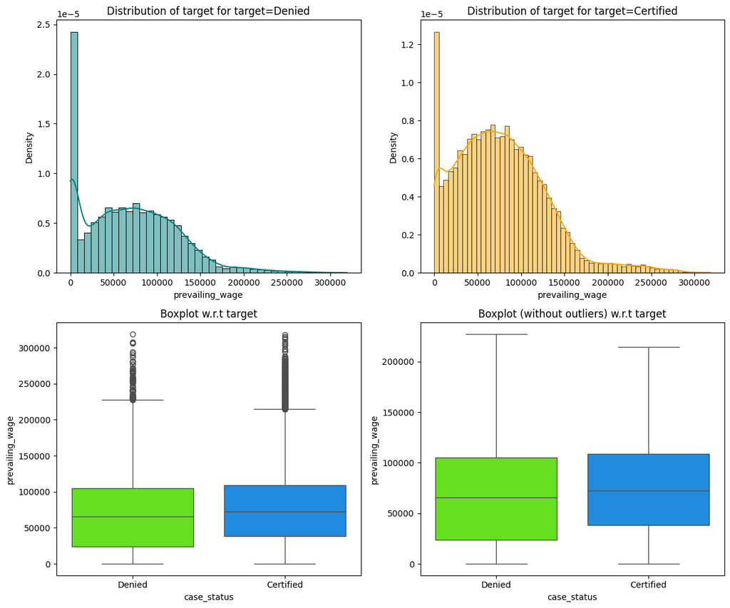

```python
## Checking distribution of prevailing wage and case status
distribution_plot_wrt_target(data, "prevailing_wage", "case_status")
```

- The distribution of both Denied and certified cases is right skewed due to outliers.
- Pervailing wage for Certified cases have slightly higher Q1,Q3 and median values in box plot with and without outliers, however the maximum value prevailing wage for denied cases is slightly higher than certified cases.
- Minimum value for both caes is similar, It looks like there may cases with 0 prevailing_wage in both cases, which required further analysis and if there is it may required to treat

```python
## Lets the number of 0 values in prevailing_wage with respect to case status
zero_counts = data.groupby('case_status')['prevailing_wage'].apply(lambda x: (x == 0).sum()).reset_index(name='zero_count')
zero_counts
```

|  | case_status | zero_count |
| --- | --- | --- |
| 0 | Certified | 0 |
| 1 | Denied | 0 |

```python
## Lets the number of less than 10 values in prevailing_wage with respect to unit of wage
Low_counts = data.groupby('unit_of_wage')['prevailing_wage'].apply(lambda x: (x <= 10).sum()).reset_index(name='zero_count')
Low_counts
```

|  | unit_of_wage | zero_count |
| --- | --- | --- |
| 0 | Hour | 14 |
| 1 | Month | 0 |
| 2 | Week | 0 |
| 3 | Year | 0 |

- As confirmed above there are no cases with 0 preaviling wage, however there are cases with <= 10 in horly unit of wage, with respect to density the distribution plot scale is quite high to get the visual of small values in prevailing wage

As all the questions has been answered, lets move to Univariate and Bivariate Analysys

# Univariate Analysis

Lets Start with dependent variable Case Status

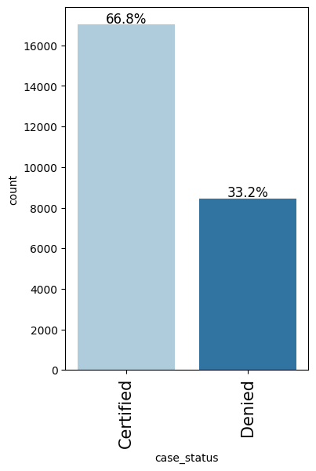

```python
## Creating labeled_barplot for case status
labeled_barplot(data, 'case_status', perc=True)
```

- 66.8% applications has been certified and 33.2% applicantions has been denied in dataset.

Observations on continent

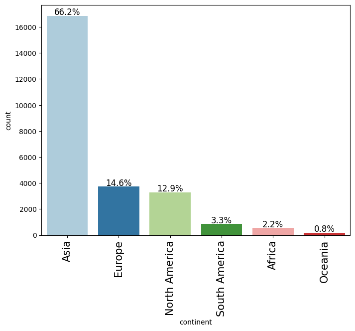

```python
labeled_barplot(data, "continent", perc=True)
```

- Applicantions from Asia continent have the highest count with 66.2%, followed by Europe with 14.6% and North America with 12.9%
- Applicantions from Oceania have the least count with 0.8%, South America and Africa have 3.3% and 2.2% of applications

Observations on education of employee

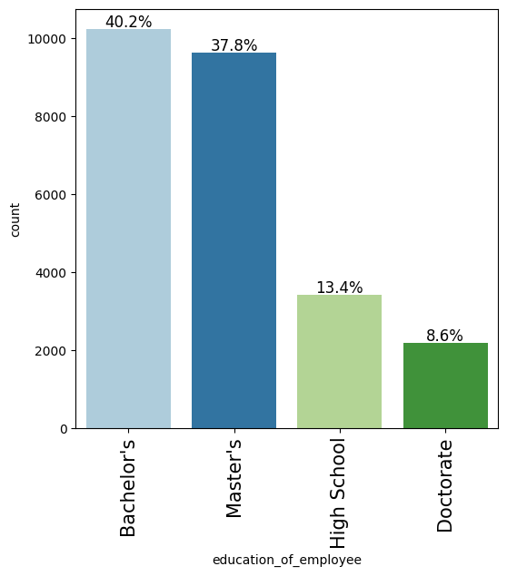

```python
## Creating labeled_barplot for education of employee
labeled_barplot(data, "education_of_employee", perc=True)
```

- Applicants with bachelors degree have highest percentage of applications with 40.2% followed by applicants with masters degree
- Doctorate have the least count only 8.6% and high school is 13.4%

Observations on job experience

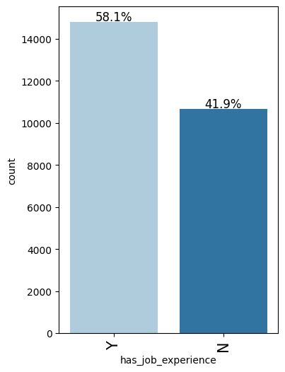

```python
## Chhecking labeled_barplot for job experience
labeled_barplot(data, "has_job_experience", perc=True)
```

- Applicants with job experience have the highest count 58.1% and Applictants with no job experience are 41.9 %.

Observations on job training

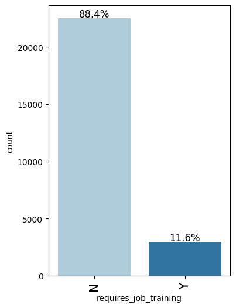

```python
## Creating labeled_barplot for job training
labeled_barplot(data, 'requires_job_training', perc=True)
```

- 88.4% Applicants do not required job training and 11.6% applicants need Job training

Observations on region of employment

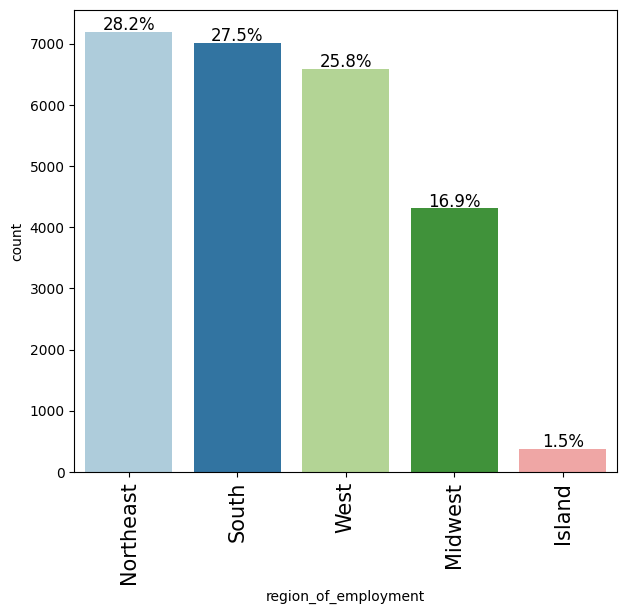

```python
## Creating labeled_barplot for region of employment
labeled_barplot(data, 'region_of_employment', perc=True)
```

- Northeast region have the highest count with 28.2% followed by South region 27.5% and west region 25.8%
- Island region have the lowest count with 1.5% only and midwest region hve 16.9% count

Observations on unit of wage

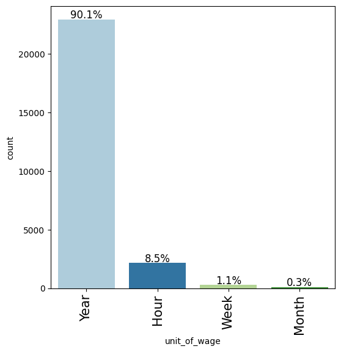

```python
## Creating labeled_barplot for unit of wage
labeled_barplot(data, 'unit_of_wage', perc=True)
```

- Yearly wages have highest count with 90.1% followed by Hourly wages,
- Monthly wages have lowest count with 0.3% and weekly wages are only 1.1% of the data.

Observations on year of establishment

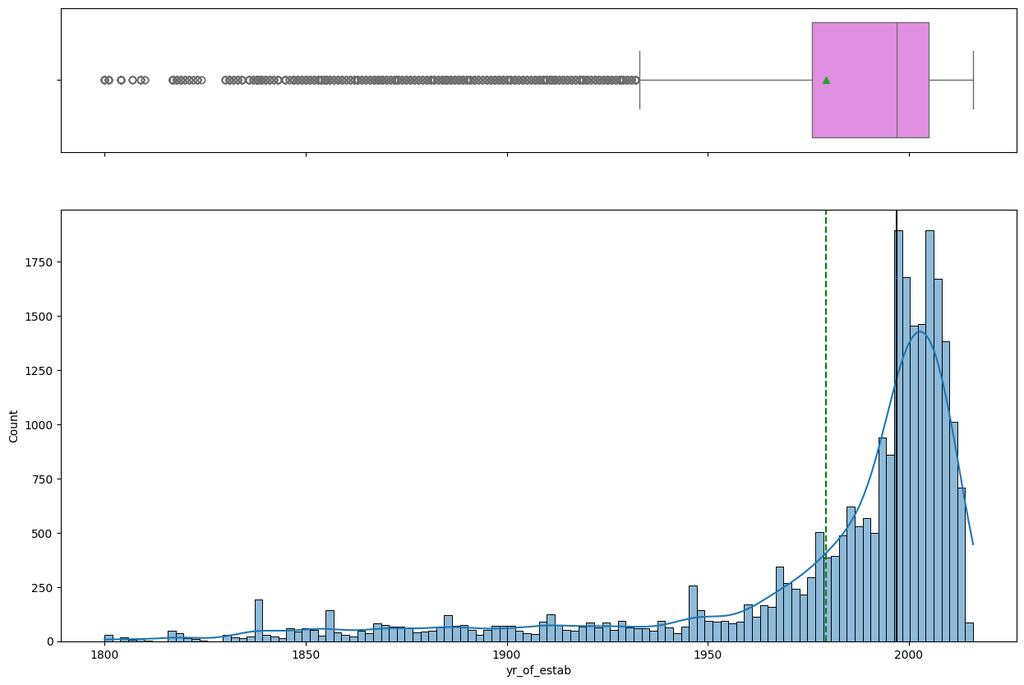

```python
# Checking distribution of yr_of_estab
histogram_boxplot(data, "yr_of_estab", kde=True)
```

- Year of established is highly left skewed, which is logical as we have compnies esablished since 1800, however most of the compnies established late 1900 and in early 2000.

# Bivariate Analysis

Let's find out if we have more relation within independent variables or with dependent variables, except what we have already checked with questions above

Checkiing impact of unit of wage on case status

```
case_status   Certified  Denied    All
unit_of_wage
All               17018    8462  25480
Year              16047    6915  22962
Hour                747    1410   2157
Week                169     103    272
Month                55      34     89
------------------------------------------------------------------------------------------------------------------------
```

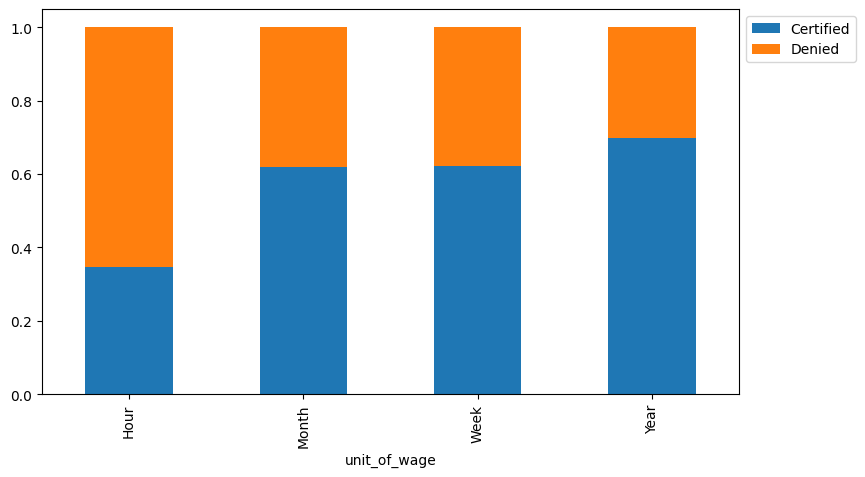

```python
##Checking unit of wage vs case status
stacked_barplot(data,'unit_of_wage','case_status')
```

- Hourly wages have highest cases of visa denied or lowest percentage of visa certified.
- Yearly wages unit have highest percentage for cases of visa certified however monthly and weekly are quite slightly lower but approximately same.

Checking distribution of prevailing wage across all the regions of the US

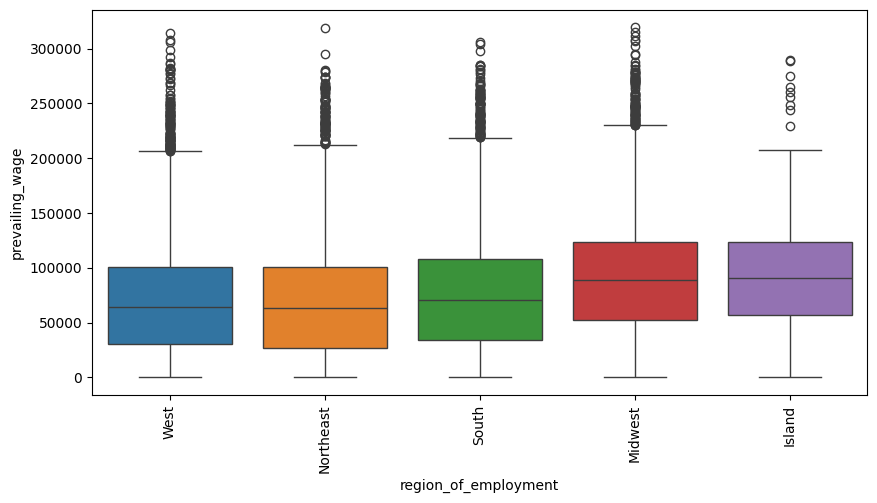

```python
## Checking boxplot for region of employment and prevailing wage
plt.figure(figsize=(10, 5))
sns.boxplot(data=data, x="region_of_employment", y="prevailing_wage", hue="region_of_employment")
plt.xticks(rotation=90)
plt.show()
```

- All regions have outliers at maximum value, however the maximum prevailing_wage is approximately similar in all regions between 200000 to 250000 range.
- Minimum value for all regions is approximately same.
- Median valued is slightly diferent for Midwest and Island region from rest of teh 3 regions, however all region falls between 50000 to 100000 range.
- Overall we can say prevailing_wage is approximately similar in all regions

Checking distribution of prevailing wage across all the continents

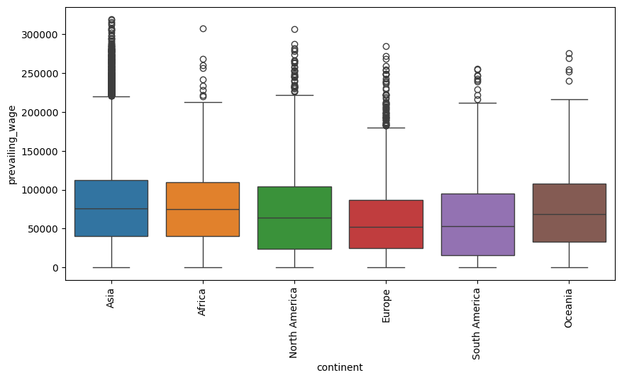

```python
## Checking boxplot for continent and prevailing wage
plt.figure(figsize=(10, 5))
sns.boxplot(data=data, x="continent", y="prevailing_wage", hue="continent")
plt.xticks(rotation=90)
plt.show()
```

- All continent's have outliers at maximum value, however the maximum prevailing_wage is approximately similar in all regions between 200000 to 250000 range, except Europe, Maximum value for Europe continent is below 200000.
- Minimum value for all regions is approximately same.
- Median valued for all continents falls between 50000 to 100000 range, it can said thet it approximately close to each other at this scale.
- Asia have highest number of outliers the as per the density of values above maximum values, which exceeds 300000

Let's check the case status across each region

```
case_status           Certified  Denied    All
region_of_employment
All                       17018    8462  25480
Northeast                  4526    2669   7195
West                       4100    2486   6586
South                      4913    2104   7017
Midwest                    3253    1054   4307
Island                      226     149    375
------------------------------------------------------------------------------------------------------------------------
```

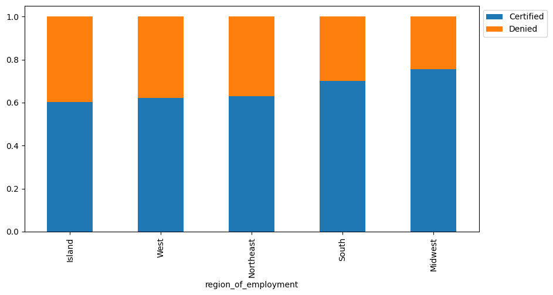

```python
## Checking stacked barplot for region of employment and case status
stacked_barplot(data, "region_of_employment", "case_status")
```

```python
# Calculate the number of approved applications for each region
approved_count = data[data['case_status'] == 'Certified'].groupby("region_of_employment").size()

print("Number of approved applications for each region:")
print(approved_count)

# Calculate the total number of applications in each region
total_count = data.groupby('region_of_employment').size()
print("\nTotal number of applications in each region:")
print(total_count)

# Calculate the percentage of approved applications
approval_percentage = (approved_count / total_count) * 100

# Print the results
print(approval_percentage)
```

```
Number of approved applications for each region:
region_of_employment
Island        226
Midwest      3253
Northeast    4526
South        4913
West         4100
dtype: int64

Total number of applications in each region:
region_of_employment
Island        375
Midwest      4307
Northeast    7195
South        7017
West         6586
dtype: int64
region_of_employment
Island       60.266667
Midwest      75.528210
Northeast    62.904795
South        70.015676
West         62.253265
dtype: float64
```

- Midwest have highest percentage of Visa certified with 75%, followed by South region with 70%
- Notheast, West and Island have almost similar percentage of visa certified between 60-63%

Let' check if type of employment have any impact on case status

```
case_status         Certified  Denied    All
full_time_position
All                     17018    8462  25480
Y                       15163    7610  22773
N                        1855     852   2707
------------------------------------------------------------------------------------------------------------------------
```

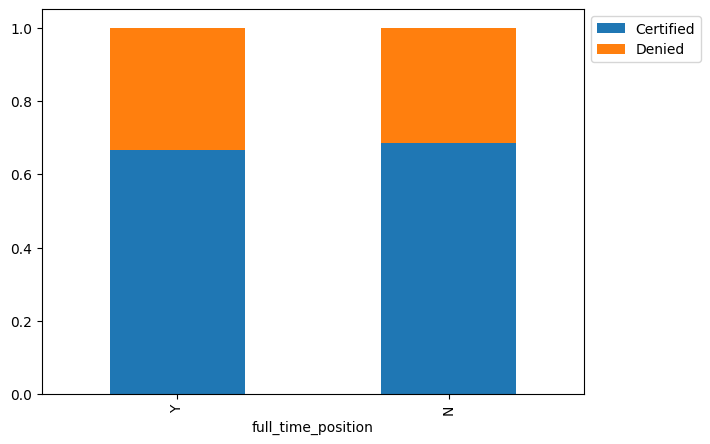

```python
## Checking stacked barplot for full_time_positio vs case status
stacked_barplot(data, "full_time_position", "case_status")
```

- Both full time and part time postions have similar amout of cases for visa certified and denied

Let's evaluate the relation between prevailing wage with full time job

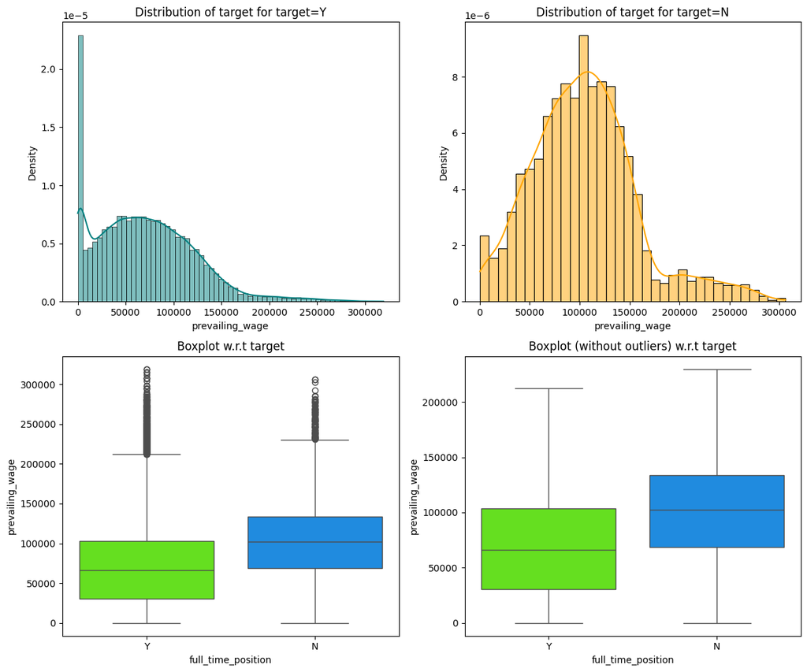

```python
## Checking distribution of prevailing wage and full time position
distribution_plot_wrt_target(data, "prevailing_wage", "full_time_position")
```

- The data is highly right skewed due to outlier's on prevailing wage.
- Q1, Q3, Median and maximum value for part time position is higher than full time position, however there are higher number of outliers on full time positions,
- Minimum value for both full time and part time positions are same.
- this seems odd that full time position have lower median and maximum value than part time positions, it might be an inconsistancy in data but that how the given data is

Let's explore education requirements in different regions

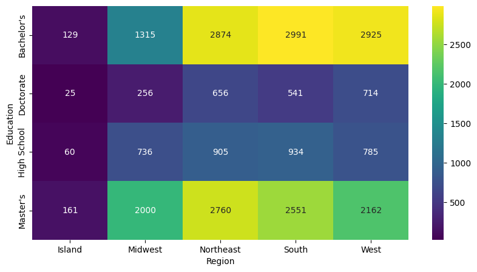

```python
## Checking relation between education and region of employment using heatmap for the crosstab
plt.figure(figsize=(10, 5))
sns.heatmap(pd.crosstab(data['education_of_employee'],data['region_of_employment']),
    annot=True,
    fmt="g",
    cmap="viridis"
)

plt.ylabel("Education")
plt.xlabel("Region")
plt.show()
```

- Applications with bachalors degree show strong relation with most of the regions, having highest count from South region followed by west and Northeast, applications form Island have the lowest count.
- Applicants with Masters degree show moderate to strong relation with most of the regions, highest count can be seen from Northwest region followed by South and west region, Island region applicatns are lowest in count and midwest is also lhave quite good number of applications
- Applicants with high school education shows week relations withall the regions, mostly count is from South region followed by Northwest region, Midwest and west region approximately similar ammount of applicants, however island have the lowest in count.
- Applicants with doctorate degree have weekest relation with all the regions as compare to other degrees, however as per the cross tab highest count from west region followed by Northeast and south region, Island region applicatns are lowest in count and midwest is also lower then top 3 regions
- Island have week relation with all the regions, Applications form west region have strong relation with bachalors degree, application from south region also have strong relation with bachalors degree, similarly applicants from Northewest region also have strong relation with bachalors degree as compare to other degrees, Applicants from Midwast have strong relation with Masters degree.

Let's check Heat map for all numerical variables if there is any correlations

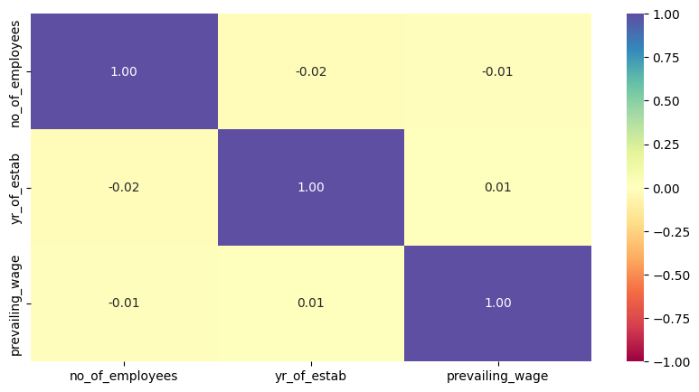

```python
## Checking the correlation between the numerical variables
cols_list = data.select_dtypes(include=np.number).columns.tolist()

plt.figure(figsize=(10, 5))
sns.heatmap(
    data[cols_list].corr(), annot=True, vmin=-1, vmax=1, fmt=".2f", cmap="Spectral"
)
plt.show()
```

- No Strong or moderate correlation has been observed within numerical variables

## Data Preprocessing

- Missing value treatment (if needed)
- Feature engineering
- Outlier detection and treatment (if needed)
- Preparing data for modeling
- Any other preprocessing steps (if needed)

Missing Value Treatment

- The data do not have any missing values, so no missing value treatment required.

Feature Engineering

- We have alreday treat the negative values, we have dropped the case_id column with all unique values. There is no more additional features required to add as the given variable data is quite expressive in terms of relationship with dependent variables.

Outlier detection

- Will perform an EDA once again just to be double sure about the outliers

In data prepration for modeling

- We want to predict which Case status, if the visa will get certified or denied, so will convert categorial values to binary values and change data type to fload or int.
- As there are quite a lot of object categorical variables, we'll have to encode categorical features, using one hot encoding technique.
- We'll split the data into train and test to be able to evaluate the model that we build on the train data

## EDA

- It is a good idea to explore the data once again after manipulating it.

Let's check Outliers on numerical variable

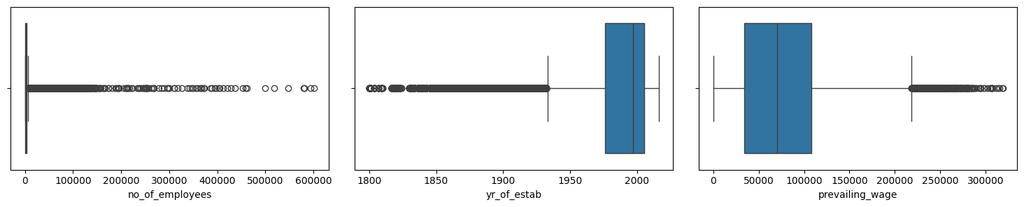

```python
# outlier detection using boxplot
numeric_columns = data.select_dtypes(include=np.number).columns.tolist()


plt.figure(figsize=(15, 12))

for i, variable in enumerate(numeric_columns):
    plt.subplot(4, 3, i + 1)
    sns.boxplot(data=data, x=variable)
    plt.tight_layout(pad=2)
plt.show()
```

- There are outlier in all numerical variables, however they can be actual values, for example Company may have been established in 1800, Prevailing wages can be >= 300000 deped upon the profession, degree and experience.
- So we'll not treat outliers, will keep them.

Let's Convert case status categories to numerical values

```python
##data["case_status"] = data["case_status"].apply(lambda x: 1 if x == "Certified" else 0)
data["case_status"] = data["case_status"].map({"Certified": 1, 'Denied': 0})

data["case_status"] = data["case_status"].astype(float)

data["case_status"].value_counts()
```

| case_status | count |
| --- | --- |
| 1.0 | 17018 |
| 0.0 | 8462 |

**dtype:** int64

Let's define X and Y (dependent and independent) variable for data set

```python
# defining (X and Y) dependent and independent variable.

#droping booking status from independent variable
X = data.drop("case_status", axis=1)

#creating dependednt variable
Y = data["case_status"]

print(X.head())
print()
print(Y.head())
```

```
  continent education_of_employee has_job_experience requires_job_training  \
0      Asia           High School                  N                     N
1      Asia              Master's                  Y                     N
2      Asia            Bachelor's                  N                     Y
3      Asia            Bachelor's                  N                     N
4    Africa              Master's                  Y                     N

   no_of_employees  yr_of_estab region_of_employment  prevailing_wage  \
0            14513         2007                 West         592.2029
1             2412         2002            Northeast       83425.6500
2            44444         2008                 West      122996.8600
3               98         1897                 West       83434.0300
4             1082         2005                South      149907.3900

  unit_of_wage full_time_position
0         Hour                  Y
1         Year                  Y
2         Year                  Y
3         Year                  Y
4         Year                  Y

0    0.0
1    1.0
2    0.0
3    0.0
4    1.0
Name: case_status, dtype: float64
```

Creating dummy variables for all columns including objects and categories

```python
# Creating dummy variables for all columns including objects and categories
X = pd.get_dummies(X, columns=X.select_dtypes(include=["object", "category"]).columns.tolist(), drop_first=True)
# Converting objects to float value for dummy variables
X = X.astype(float)
X.head()
```

|  | no_of_employees | yr_of_estab | prevailing_wage | continent_Asia | continent_Europe | continent_North America | continent_Oceania | continent_South America | education_of_employee_Doctorate | education_of_employee_High School | education_of_employee_Master's | has_job_experience_Y | requires_job_training_Y | region_of_employment_Midwest | region_of_employment_Northeast | region_of_employment_South | region_of_employment_West | unit_of_wage_Month | unit_of_wage_Week | unit_of_wage_Year | full_time_position_Y |
| --- | --- | --- | --- | --- | --- | --- | --- | --- | --- | --- | --- | --- | --- | --- | --- | --- | --- | --- | --- | --- | --- |
| 0 | 14513.0 | 2007.0 | 592.2029 | 1.0 | 0.0 | 0.0 | 0.0 | 0.0 | 0.0 | 1.0 | 0.0 | 0.0 | 0.0 | 0.0 | 0.0 | 0.0 | 1.0 | 0.0 | 0.0 | 0.0 | 1.0 |
| 1 | 2412.0 | 2002.0 | 83425.6500 | 1.0 | 0.0 | 0.0 | 0.0 | 0.0 | 0.0 | 0.0 | 1.0 | 1.0 | 0.0 | 0.0 | 1.0 | 0.0 | 0.0 | 0.0 | 0.0 | 1.0 | 1.0 |
| 2 | 44444.0 | 2008.0 | 122996.8600 | 1.0 | 0.0 | 0.0 | 0.0 | 0.0 | 0.0 | 0.0 | 0.0 | 0.0 | 1.0 | 0.0 | 0.0 | 0.0 | 1.0 | 0.0 | 0.0 | 1.0 | 1.0 |
| 3 | 98.0 | 1897.0 | 83434.0300 | 1.0 | 0.0 | 0.0 | 0.0 | 0.0 | 0.0 | 0.0 | 0.0 | 0.0 | 0.0 | 0.0 | 0.0 | 0.0 | 1.0 | 0.0 | 0.0 | 1.0 | 1.0 |
| 4 | 1082.0 | 2005.0 | 149907.3900 | 0.0 | 0.0 | 0.0 | 0.0 | 0.0 | 0.0 | 0.0 | 1.0 | 1.0 | 0.0 | 0.0 | 0.0 | 1.0 | 0.0 | 0.0 | 0.0 | 1.0 | 1.0 |

```python
#Checking number of columsn and rows for independent variables
X.shape
```

```
(25480, 21)
```

```python
#checking the data type of variables, just  to confirm
X.info()
```

```
<class 'pandas.core.frame.DataFrame'>
RangeIndex: 25480 entries, 0 to 25479
Data columns (total 21 columns):
 #   Column                             Non-Null Count  Dtype
---  ------                             --------------  -----
 0   no_of_employees                    25480 non-null  float64
 1   yr_of_estab                        25480 non-null  float64
 2   prevailing_wage                    25480 non-null  float64
 3   continent_Asia                     25480 non-null  float64
 4   continent_Europe                   25480 non-null  float64
 5   continent_North America            25480 non-null  float64
 6   continent_Oceania                  25480 non-null  float64
 7   continent_South America            25480 non-null  float64
 8   education_of_employee_Doctorate    25480 non-null  float64
 9   education_of_employee_High School  25480 non-null  float64
 10  education_of_employee_Master's     25480 non-null  float64
 11  has_job_experience_Y               25480 non-null  float64
 12  requires_job_training_Y            25480 non-null  float64
 13  region_of_employment_Midwest       25480 non-null  float64
 14  region_of_employment_Northeast     25480 non-null  float64
 15  region_of_employment_South         25480 non-null  float64
 16  region_of_employment_West          25480 non-null  float64
 17  unit_of_wage_Month                 25480 non-null  float64
 18  unit_of_wage_Week                  25480 non-null  float64
 19  unit_of_wage_Year                  25480 non-null  float64
 20  full_time_position_Y               25480 non-null  float64
dtypes: float64(21)
memory usage: 4.1 MB
```

- All the values are converted to float data type, so we are good to go ached with data preparation.

Let's split data into test and train sets with 70:30 ratio

```python
# Splitting data in train and test sets in the ratio 70:30
X_train, X_test, Y_train, Y_test = train_test_split(X, Y, test_size=0.30, random_state=1, stratify=Y)

print("Shape of Training set : ", X_train.shape)
print("Shape of test set : ", X_test.shape)
print("Percentage of classes in training set:")
print(Y_train.value_counts(normalize=True))
print("Percentage of classes in test set:")
print(Y_test.value_counts(normalize=True))
```

```
Shape of Training set :  (17836, 21)
Shape of test set :  (7644, 21)
Percentage of classes in training set:
case_status
1.0    0.667919
0.0    0.332081
Name: proportion, dtype: float64
Percentage of classes in test set:
case_status
1.0    0.667844
0.0    0.332156
Name: proportion, dtype: float64
```

### Model evaluation criterion

- If Model predicts that the visa application will get certified when it had to be denied a wrong employee will get the job position while US citizens will miss the opportunity to work on that position.
- If Model predicts that the visa application will not get certified when it had to be certified the U.S. will lose a suitable candidate that can contribute to the economy.
- So both the cases are important, so `F1 Score` can be used a the metric for evaluation of the model, greater the F1 score higher are the chances of minimizing False Negatives and False Positives.
- We will use balanced class weights so that model focuses equally on both classes.

## Building bagging and boosting models

**Note**

1. Sample parameter grids have been provided to do necessary hyperparameter tuning. These sample grids are expected to provide a balance between model performance improvement and execution time. One can extend/reduce the parameter grid based on execution time and system configuration.
- Please note that if the parameter grid is extended to improve the model performance further, the execution time will increase
- For Gradient Boosting:

```
param_grid = {
    "init": [AdaBoostClassifier(random_state=1),DecisionTreeClassifier(random_state=1)],
    "n_estimators": np.arange(50,110,25),
    "learning_rate": [0.01,0.1,0.05],
    "subsample":[0.7,0.9],
    "max_features":[0.5,0.7,1],
}
```

- For Adaboost:

```
param_grid = {
    "n_estimators": np.arange(50,110,25),
    "learning_rate": [0.01,0.1,0.05],
    "base_estimator": [
        DecisionTreeClassifier(max_depth=2, random_state=1),
        DecisionTreeClassifier(max_depth=3, random_state=1),
    ],
}
```

- For Bagging Classifier:

```
param_grid = {
    'max_samples': [0.8,0.9,1],
    'max_features': [0.7,0.8,0.9],
    'n_estimators' : [30,50,70],
}
```

- For Random Forest:

```
param_grid = {
    "n_estimators": [50,110,25],
    "min_samples_leaf": np.arange(1, 4),
    "max_features": [np.arange(0.3, 0.6, 0.1),'sqrt'],
    "max_samples": np.arange(0.4, 0.7, 0.1)
}
```

- For Decision Trees:

```
param_grid = {
    'max_depth': np.arange(2,6),
    'min_samples_leaf': [1, 4, 7],
    'max_leaf_nodes' : [10, 15],
    'min_impurity_decrease': [0.0001,0.001]
}
```

- For XGBoost:

```
param_grid={'n_estimators':np.arange(50,110,25),
            'scale_pos_weight':[1,2,5],
            'learning_rate':[0.01,0.1,0.05],
            'gamma':[1,3],
            'subsample':[0.7,0.9]
}
```

- We have pre defined hyperparameters for tuning models, however to improve further will tune the parameters and use the best preforming models for project

As we are using classification models lets define function to check Model performance

```python
def confusion_matrix_sklearn(model, predictors, target):
    """
    To plot the confusion_matrix with percentages

    model: classifier
    predictors: independent variables
    target: dependent variable
    """
    y_pred = model.predict(predictors)
    cm = confusion_matrix(target, y_pred)
    labels = np.asarray(
        [
            ["{0:0.0f}".format(item) + "\n{0:.2%}".format(item / cm.flatten().sum())]
            for item in cm.flatten()
        ]
    ).reshape(2, 2)

    plt.figure(figsize=(6, 4))
    sns.heatmap(cm, annot=labels, fmt="")
    plt.ylabel("True label")
    plt.xlabel("Predicted label")
```

```python
# defining a function to compute different metrics to check performance of a classification model built using sklearn
def model_performance_classification_sklearn(model, predictors, target):
    """
    Function to compute different metrics to check classification model performance

    model: classifier
    predictors: independent variables
    target: dependent variable
    """

    # predicting using the independent variables
    pred = model.predict(predictors)

    acc = accuracy_score(target, pred)  # to compute Accuracy
    recall = recall_score(target, pred)  # to compute Recall
    precision = precision_score(target, pred)  # to compute Precision
    f1 = f1_score(target, pred)  # to compute F1-score

    # creating a dataframe of metrics
    df_perf = pd.DataFrame(
        {"Accuracy": acc, "Recall": recall, "Precision": precision, "F1": f1,},
        index=[0],
    )

    return df_perf
```

Let's Start with Decision Tree Model and check performance on test and train data with default values and with tuned hyper parameters

```python
## Building decision tree classifier with random state = 1
model = DecisionTreeClassifier(class_weight="balanced", random_state=1)
## fitting decision tree classifier on the train data
model.fit(X_train, Y_train)
```

```
DecisionTreeClassifier(class_weight='balanced', random_state=1)
```

Checking Model performance on training and test data

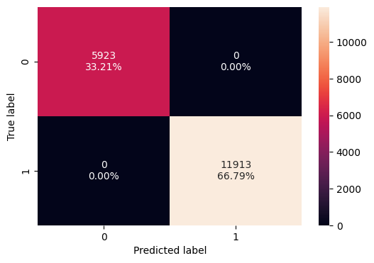

```python
## Creating confusion matrix for train data
confusion_matrix_sklearn(model, X_train, Y_train)
```

```python
## Checking performance on train data
decision_tree_perf_train = model_performance_classification_sklearn(model, X_train, Y_train)
decision_tree_perf_train
```

|  | Accuracy | Recall | Precision | F1 |
| --- | --- | --- | --- | --- |
| 0 | 1.0 | 1.0 | 1.0 | 1.0 |

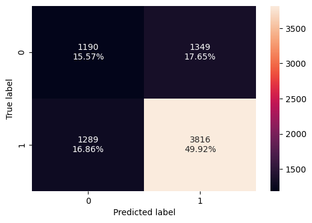

```python
## Creating confusion matrix for test data
confusion_matrix_sklearn(model, X_test, Y_test)
```

```python
## Checking performance for test data
decision_tree_perf_test = model_performance_classification_sklearn(model, X_test, Y_test)
decision_tree_perf_test
```

|  | Accuracy | Recall | Precision | F1 |
| --- | --- | --- | --- | --- |
| 0 | 0.654893 | 0.747502 | 0.738819 | 0.743135 |

- As we know a decision tree will continue to grow and classify each data point correctly if no restrictions are applied as the trees will learn all the patterns in the training set. This generally leads to overfitting of the model as Decision Tree will perform well on the training set but will fail to replicate the performance on the test set.
- The discrepancy between the F1 scores on the test and train sets is a clear sign of overfitting, where the model is too specialized to the training data and not generalizing well to unseen data.

Hyperparameter Tuning - Decision Tree

```python
# Defining classifier with new hyperarameters.
dtree_estimator = DecisionTreeClassifier(class_weight="balanced", random_state=1)

# Grid of parameters to choose from
parameters = {
    "max_depth": list(np.arange(2,20)) + [None],
    "min_samples_leaf": [1, 3, 5, 7, 10],
    "max_leaf_nodes": [2, 3, 5, 10, 15] + [None],
    "min_impurity_decrease": [0.001, 0.01, 0.1, 0.0],
}

# Type of scoring used to compare parameter combinations
scorer = metrics.make_scorer(metrics.f1_score)

# Run the grid search with n_jobs = -1
grid_obj = GridSearchCV(dtree_estimator, parameters, scoring=scorer, n_jobs= -1 ,cv=5)

 ## Fitting the grid_obj on the train data
grid_obj = grid_obj.fit(X_train, Y_train)


# Set the clf to the best combination of parameters
dtree_estimator = grid_obj.best_estimator_

# Fit the best algorithm to the data.
dtree_estimator.fit(X_train, Y_train)
```

```
DecisionTreeClassifier(class_weight='balanced', max_depth=2, max_leaf_nodes=2,
                       min_impurity_decrease=0.001, random_state=1)
```

Checking Model performance on train and test data

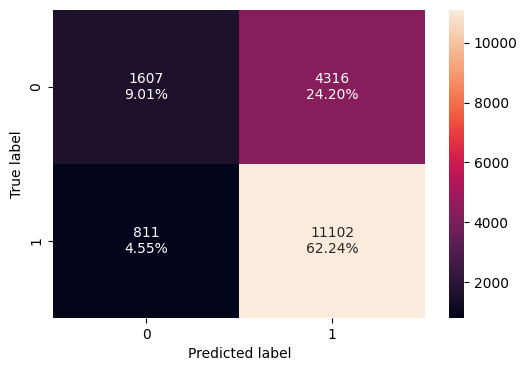

```python
## Creating confusion matrix for train data on tuned estimator
confusion_matrix_sklearn(dtree_estimator, X_train, Y_train)
```

```python
## Checking performance for train data on tuned estimator
dtree_estimator_model_train_perf = model_performance_classification_sklearn(dtree_estimator, X_train, Y_train)
dtree_estimator_model_train_perf
```

|  | Accuracy | Recall | Precision | F1 |
| --- | --- | --- | --- | --- |
| 0 | 0.712548 | 0.931923 | 0.720067 | 0.812411 |

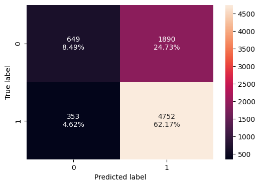

```python
## Creating confusion matrix for test data on tuned estimator
confusion_matrix_sklearn(dtree_estimator, X_test, Y_test)
```

```python
## Checking performance for train data on tuned estimator
dtree_estimator_model_test_perf = model_performance_classification_sklearn(dtree_estimator, X_test, Y_test)
dtree_estimator_model_test_perf
```

|  | Accuracy | Recall | Precision | F1 |
| --- | --- | --- | --- | --- |
| 0 | 0.706567 | 0.930852 | 0.715447 | 0.809058 |

- Improvement has been observed on F1 score post using revised hypertuning parameters, model is able to generalize well on unseen data.

Let's check feature importance in decision tree hyper tuned model 1

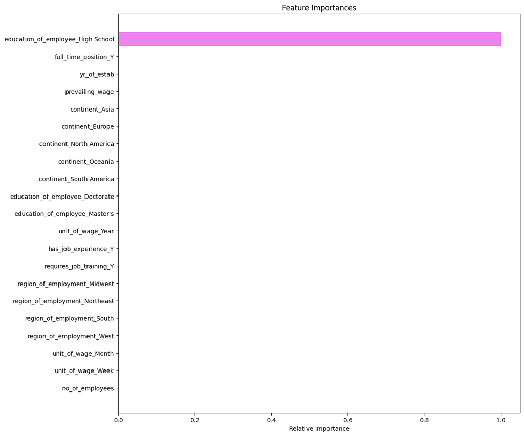

```python
# importance of features in the tree building
feature_names = X_train.columns
importances = dtree_estimator.feature_importances_
indices = np.argsort(importances)

plt.figure(figsize=(12,12))
plt.title('Feature Importances')
plt.barh(range(len(indices)), importances[indices], color='violet', align='center')
plt.yticks(range(len(indices)), [feature_names[i] for i in indices])
plt.xlabel('Relative Importance')
plt.show()
```

- As per the estimator there is only 1 important feature in all the independent variable, which seems to a concern in decision tree model, lets try other models and check the performance

Let's move to Bagging Classifier model and check how is the performance on data set

```python
## BUilding bagging classifier with random state = 1
bagging_classifier =  BaggingClassifier(random_state=1)

## Fitting bagging classifier on the train data
bagging_classifier.fit(X_train, Y_train)
```

```
BaggingClassifier(random_state=1)
```

Checking model performance on train and test data set

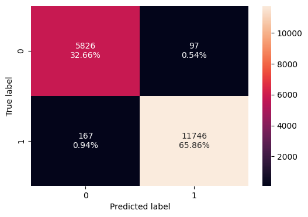

```python
## Checking Confusion matrix for train data
confusion_matrix_sklearn(bagging_classifier, X_train, Y_train)
```

```python
## Checking performance on train data
bagging_classifier_model_train_perf = model_performance_classification_sklearn(bagging_classifier, X_train, Y_train)
bagging_classifier_model_train_perf
```

|  | Accuracy | Recall | Precision | F1 |
| --- | --- | --- | --- | --- |
| 0 | 0.985198 | 0.985982 | 0.99181 | 0.988887 |

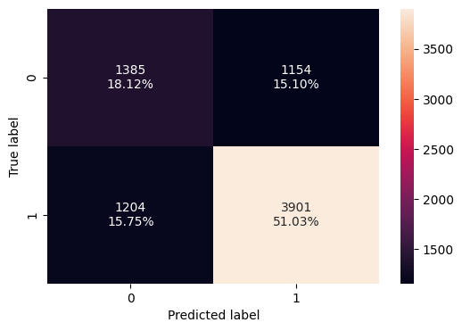

```python
## Checking Confusion matrix for train data
confusion_matrix_sklearn(bagging_classifier, X_test, Y_test)
```

```python
 ## Checking performance on train data
bagging_classifier_model_test_perf = model_performance_classification_sklearn(bagging_classifier, X_test, Y_test)
bagging_classifier_model_test_perf
```

|  | Accuracy | Recall | Precision | F1 |
| --- | --- | --- | --- | --- |
| 0 | 0.691523 | 0.764153 | 0.771711 | 0.767913 |

- The discrepancy between the F1 scores on the test and train sets is indication of overfitting, where the model is doing quite well on the training data and not generalizing well to unseen test data.